# Trump Visualizations

Bryce Wolery

April 24, 2017

## Setup

These are the required packages to manipulate the data and create the following visualizations.

```r
suppressWarnings(require(data.table))
suppressWarnings(require(dplyr))
suppressWarnings(require(magrittr))
suppressWarnings(require(stringr))
suppressWarnings(require(ggplot2))
suppressWarnings(require(plotly))
#require(packrat)  # Required to publish as html
#require(rsconnect)  # Required to publish as html
```

## Read and Format Data

```r
## Read in data ##
data_path <- "~/Trump-Tweets/data/clean_data/"  # Path to clean data
subject_names <- list.files(data_path) %>% .[grep("[.]csv", .)] %>%
                    lapply(., function(name) str_replace(string=name, pattern=".csv", replacement="")) %>%
                        unlist(.)
# Get list of twitter handles in our data set (name of csv files, remove .csv)

tweets <- lapply(seq(length(subject_names)),function(x) fread(paste0(data_path, subject_names[x], ".csv"))) %>%
              set_names(., subject_names)  # Corpus as a list of data frames

subject_names  # List of twitter accounts
```

```
##  [1] "agscottpruitt"   "ajitpaifcc"      "andypuzder"
##  [4] "citizens_united" "clewandowski_"   "coburnforsenate"
##  [7] "danscavino"      "darrellissa"     "david_bossie"
## [10] "donaldjtrumpjr"  "erictrump"       "genflynn"
## [13] "governorperry"   "govhaleysc"      "govpencein"
## [16] "hillaryclinton"  "ivankatrump"     "jasoninthehouse"
## [19] "jasonmillerindc" "kellyannepolls"  "larry_kudlow"
## [22] "linda_mcmahon"   "lindseygrahamsc" "marcorubio"
## [25] "michaelcohen212" "monicacrowley"   "nikkihaley"
## [28] "pambondi"        "petehoekstra"    "potus"
## [31] "presssec"        "realbencarson"   "realdonaldtrump"
## [34] "reince"          "repmickmulvaney" "repmikepompeo"
## [37] "repmikerogers"   "reptomprice"     "rogerjstonejr"
## [40] "ryanzinke"       "sarahpalinusa"   "scaramucci"
## [43] "scottpruittok"   "seanhannity"     "seanspicer"
## [46] "sebgorka"        "senatemajldr"    "senatorsessions"
## [49] "sendancoats"     "senjohnmccain"   "sheriffclarke"
## [52] "shsanders45"     "speakerryan"     "stephenbannon"
## [55] "tedcruz"         "vitielloronald"  "vp"
## [58] "whignewtons"     "whitehouse"
```

We collected data for the above accounts.

## Sentiment Analysis Visualizations

#### Output of Sentiment Analysis Model

The result of the sentiment analysis model was added as another field to the clean data files called ‘compound_polarity’. I first created an empty data table and iteratively filled in each entry of the table with the relevant summary information for each account. I then created the scatterplot as a gg object before converting it to an interactive plotly object (hovering over each point displays the Twitter account with average polarity in parentheses, average of positive tweets, and average of negative tweets).

```r
polarity <- data.table(Name = subject_names,
                       Neg = rep(0, length(subject_names)),
                       Pos = rep(0, length(subject_names)),
                       Avg = rep(0, length(subject_names)))
# Create empty table to fill in with polarity data

for (k in seq(length(subject_names))) {
  polarity$Neg[k] <- abs(mean(tweets[[k]]$compound_polarity[which(sign(tweets[[k]]$compound_polarity)==-1)]))
  polarity$Pos[k] <- mean(tweets[[k]]$compound_polarity[which(sign(tweets[[k]]$compound_polarity)==1)])
  polarity$Avg[k] <- mean(tweets[[k]]$compound_polarity)
}  # Fill in polarity table

sentiment <- ggplot(data=polarity, aes(x=Neg, y=Pos)) +
               geom_point(aes(text=sprintf("%s (%s)", Name, round(Avg, 2))), color="green") +
                ggtitle("Sentiment Analysis") + labs(x="Abs. Value of Negative Tweets", y="Positive Tweets") +
                    geom_line(aes(x=seq(0, 1, length.out = 59), y=seq(0, 1, length.out = 59)), color="blue") +
                        xlim(c(0.3, 0.7)) + ylim(c(0.3, 0.7))  # gg object for scatterplot
sentiment_plot <- ggplotly(sentiment)  # Turn gg object into interactive plotly object
sentiment_plot
```

[interactive chart not shown]

This figure illustrates the results of the sentiment model on the relevant Twitter accounts for which we have data. Each green point represents a Twitter account, where the x-coordinate is the absolute value of the mean polarity of negative tweets and the y-coordinate is the mean polarity of positive tweets. The points above the blue line, “y = x”, are accounts where their positive tweets are more positive than their negative tweets, and vice versa for tweets below the blue line.

#### Breakdown of Tweets by Sentiment

```r
trump_tweets <- tweets[["realdonaldtrump"]]  # Data table of only Trump's tweets
hillary_tweets <- tweets[["hillaryclinton"]]  # Data table of only Clinton's tweets
baseline <- fread("~/Downloads/baseline_tweets.csv")  # Baseline cohort tweets
```

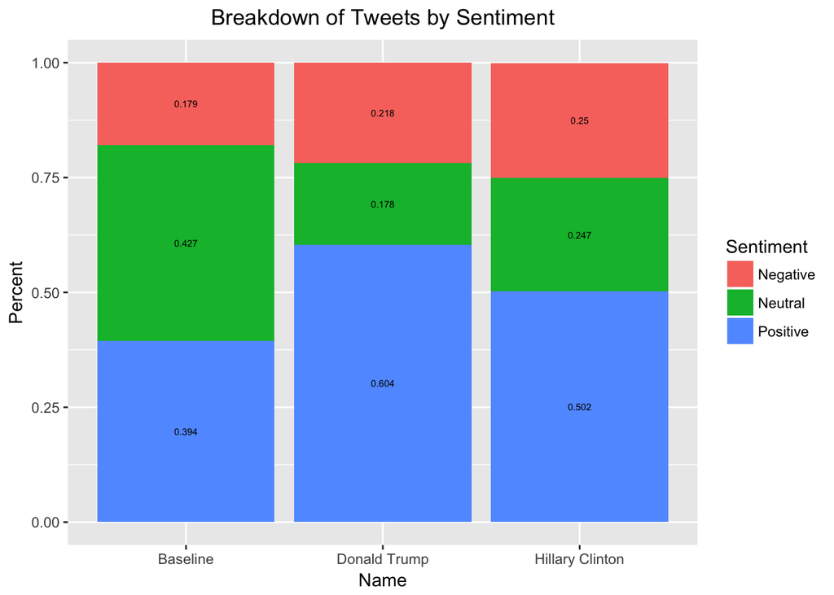

```r
slices_trump <- c(sum(which(sign(trump_tweets$compound_polarity)==1)),
                  sum(which(sign(trump_tweets$compound_polarity)==-1)),
                  sum(which(trump_tweets$compound_polarity==0)))

slices_hillary <- c(sum(which(sign(hillary_tweets$compound_polarity)==1)),
                    sum(which(sign(hillary_tweets$compound_polarity)==-1)),
                    sum(which(hillary_tweets$compound_polarity==0)))

slices_baseline <-  c(sum(which(sign(baseline$compound_polarity)==1)),
                      sum(which(sign(baseline$compound_polarity)==-1)),
                      sum(which(baseline$compound_polarity==0)))

compare_sent_tbl <- data.table(Name = c(rep("Donald Trump", 3), rep("Hillary Clinton", 3), rep("Baseline", 3)),
                               Sentiment = rep(c("Positive", "Neutral", "Negative"), 3),
                               Percent = c(round(slices_trump[1]/sum(slices_trump), 3),
                                           round(slices_trump[3]/sum(slices_trump), 3),
                                           round(slices_trump[2]/sum(slices_trump), 3),
                                           round(slices_hillary[1]/sum(slices_hillary), 3),
                                           round(slices_hillary[3]/sum(slices_hillary), 3),
                                           round(slices_hillary[2]/sum(slices_hillary), 3),
                                           round(slices_baseline[1]/sum(slices_baseline), 3),
                                           round(slices_baseline[3]/sum(slices_baseline), 3),
                                           round(slices_baseline[2]/sum(slices_baseline), 3)))

ggplot(compare_sent_tbl, aes(x=Name, y=Percent, fill=Sentiment)) + theme(plot.title = element_text(hjust = 0.5)) +
  geom_bar(stat="identity") + ggtitle("Breakdown of Tweets by Sentiment") +
  geom_text(aes(label = Percent), position = position_stack(vjust = 0.5), size = 2)
```

This figure is a stacked bar chart displaying the relative frequency of positive, neutral, and negative tweets for our baseline data set, Donald Trump, and Hillary Clinton. Donald Trump (60.4%) has relatively more tweets characterized as positive than Hillary Clinton (50.2%), but each is markedly more positive than our baseline cohort of random tweets (39.4%). However, 42.7% of tweets in the baseline cohort were neutral in sentiment, which is much more than the 17.8% of neutral tweets for Donald Trump and 24.7% of neutral tweets for Hillary Clinton. This is evidence that Donald Trump and Hillary Clinton are largely either positive or negative as opposed to neutral when expressing views through Twitter.

#### Distributions of Sentiments for Trump and Clinton

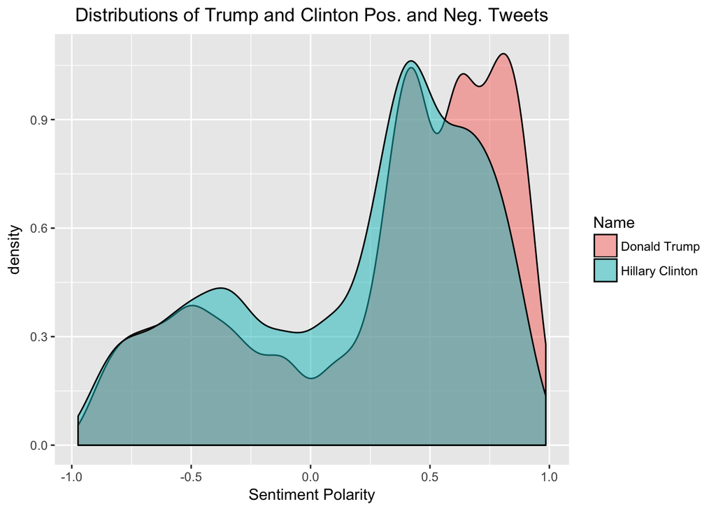

```r
trump_tweets$Name <- "Donald Trump"
hillary_tweets$Name <- "Hillary Clinton"
trump_hillary_tweets <- rbind(trump_tweets, hillary_tweets)
trump_hillary_tweets_no0 <- trump_hillary_tweets[compound_polarity!=0]

ggplot(trump_hillary_tweets_no0, aes(x=compound_polarity, fill=Name)) + geom_density(alpha=0.5) +
  ggtitle("Distributions of Trump and Clinton Pos. and Neg. Tweets") + theme(plot.title = element_text(hjust = 0.5)) +
  xlab("Sentiment Polarity")
```

This figure compares the distributions of sentiment polarity for Donald Trump’s and Hillary Clinton’s positive and negative tweets for their entire history on Twitter. Each distribution is approximately bimodal with most of the mass on the positive end. However, the distribution for Donald Trump’s tweets has more mass towards the positive end than Hillary Clinton’s distribution, indicating that Donald Trump’s tweets are more polarized in the positive direction while Hillary Clinton’s tweets are more moderate in sentiment.

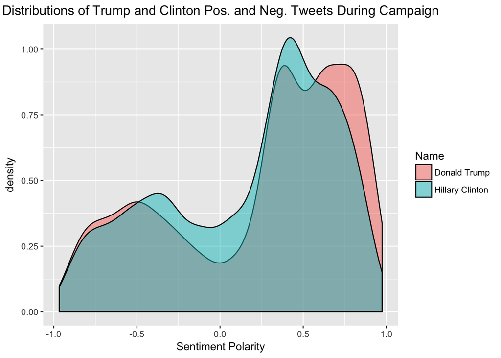

```r
campaignTrump <- fread("~/Downloads/campaignTrump.csv")
campaignHillary <- fread("~/Downloads/campaignHillary.csv")

campaignTrump$Name <- rep("Donald Trump", nrow(campaignTrump))
campaignHillary$Name <- rep("Hillary Clinton", nrow(campaignHillary))

campaign <- rbind(campaignHillary, campaignTrump)
campaign <- campaign[compound_polarity!=0]

ggplot(campaign, aes(x=compound_polarity, fill=Name)) + geom_density(alpha=0.5) +
  ggtitle("Distributions of Trump and Clinton Pos. and Neg. Tweets During Campaign") + theme(plot.title = element_text(hjust = 0.5)) +
  xlab("Sentiment Polarity")
```

This figure displays the distributions of sentiment polarity for Donald Trump’s and Hillary Clinton’s positive and negative tweets during the campaign. The distribution of Hillary Clinton’s tweets is very similar to that of her entire Twitter history, but Donald Trump’s sentiment becomes more moderate.